# SC19: Quiz 01

October 16, 2019. 1:30 PM – 2:30 PM

# Problem 1 [20 pts]

### From the wine data given, reproduce the following plots as exactly as possible. Do not change size, alpha, and coordinate range from the default setting.

```r
wine <- read_csv("./quiz-1.csv")
head(wine)
```

```
## # A tibble: 6 x 13
##   type  fixed_acidity volatile_acidity citric_acid residual_sugar chlorides
##   <chr>         <dbl>            <dbl>       <dbl>          <dbl>     <dbl>
## 1 red             7.4             0.7         0               1.9     0.076
## 2 red             7.8             0.88        0               2.6     0.098
## 3 red             7.8             0.76        0.04            2.3     0.092
## 4 red            11.2             0.28        0.56            1.9     0.075
## 5 red             7.4             0.7         0               1.9     0.076
## 6 red             7.4             0.66        0               1.8     0.075
## # ... with 7 more variables: free_sulfur_dioxide <dbl>,
## #   total_sulfur_dioxide <dbl>, density <dbl>, pH <dbl>, sulphates <dbl>,
## #   alcohol <dbl>, quality <chr>
```

**a) [8 pts]**

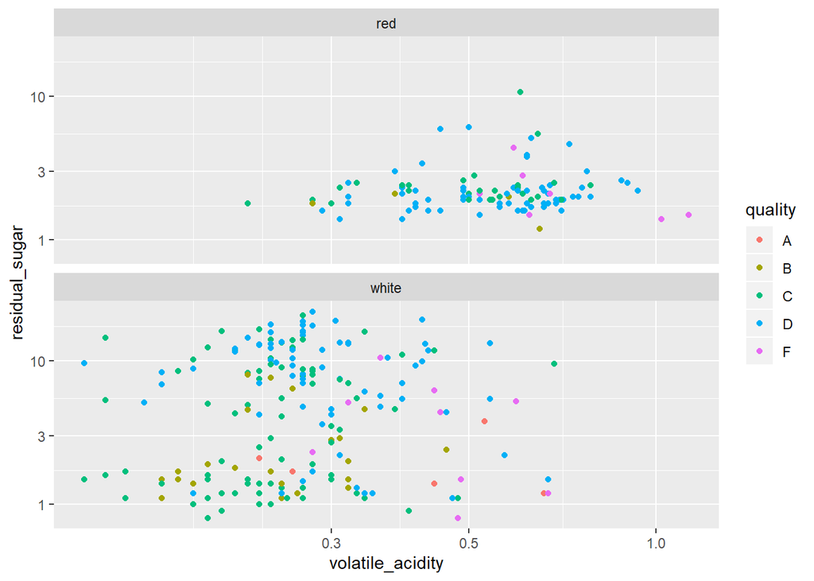

```r
ggplot(wine, aes(volatile_acidity, residual_sugar, color=quality)) +
  geom_point() +
  facet_wrap(.~type, nrow=2) +
  scale_x_log10() +
  scale_y_log10()
```

**b) [12 pts]**

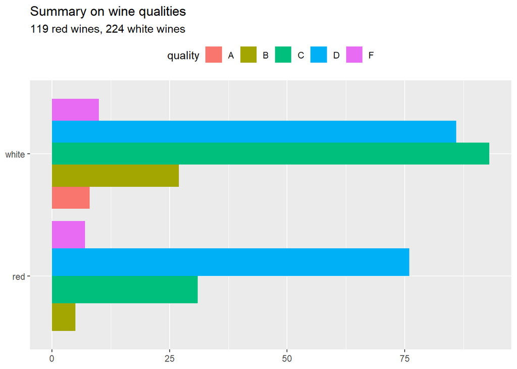

```r
ggplot(wine, aes(x=type)) +
  geom_bar(aes(fill=quality), position="dodge") +
  coord_flip() +
  labs(
    title = "Summary on wine qualities",
    subtitle = "119 red wines, 224 white wines",
    x = NULL,
    y = NULL
  ) +
  theme(legend.position = "top")
```

# Problem 2 [20 pts]

### We give you the following `lam_wf` data; every subproblem in problem 2 uses this dataset. This data set is the simplified version of the datasets that consists of the engineering variables from a LAM 9600 Metal Etcher over the course of etching 129 wafers. For more information about the original data set, please see:

[output not shown]

```r
lam_wf <- read.csv('./lam_data.csv')
lam_wf %>% head
```

```
##      Time Step_Number RF_Btm_Pwr RF_Rfl_Pwr Pressure RF_Tuner TCP_Tuner
## 1 11.9460           4        132          0     1227     9408     20028
## 2 13.0280           4        134          0     1229     9431     20042
## 3 14.0490           4        134          0     1221     9389     20146
## 4 15.1329           4        133          0     1201     9445     20148
## 5 16.1390           4        132          0     1182     9456     20226
## 6 17.1589           4        134          0     1144     9406     19478
##   TCP_Top_Pwr Vat_Valve  batch_id
## 1         360        49 l2901.txm
## 2         350        49 l2901.txm
## 3         344        49 l2901.txm
## 4         352        50 l2901.txm
## 5         346        50 l2901.txm
## 6         350        49 l2901.txm
```

**a) [10 pts]**

```r
lam_wf %>%
  group_by(batch_id) %>%
  arrange(batch_id, Time) %>%
  mutate(
    nearest_time = lag(Time),
    time_diff = abs(Time - nearest_time)
  ) %>%
  summarize(
    mean_time_diff = mean(time_diff, na.rm = TRUE)
  ) %>%
  arrange(desc(mean_time_diff))
```

```
## # A tibble: 108 x 2
##    batch_id  mean_time_diff
##    <fct>              <dbl>
##  1 l2903.txm           1.06
##  2 l2904.txm           1.05
##  3 l2901.txm           1.05
##  4 l2905.txm           1.05
##  5 l2902.txm           1.04
##  6 l2942.txm           1.04
##  7 l3326.txm           1.03
##  8 l3130.txm           1.03
##  9 l3112.txm           1.03
## 10 l3322.txm           1.03
## # ... with 98 more rows
```

> Batch l2903.txm has maximum mean time difference with 1.06

**b) [10 pts]**

```r
lam_wf %>%
  group_by(batch_id, Step_Number) %>%
  summarize(mean_pressure = mean(Pressure)) %>%
  group_by(batch_id) %>%
  filter(min_rank(desc(mean_pressure)) == 1)
```

```
## # A tibble: 108 x 3
## # Groups:   batch_id [108]
##    batch_id  Step_Number mean_pressure
##    <fct>           <int>         <dbl>
##  1 l2901.txm           4         1189.
##  2 l2902.txm           4         1189.
##  3 l2903.txm           4         1188.
##  4 l2904.txm           4         1189.
##  5 l2905.txm           4         1189.
##  6 l2906.txm           4         1190.
##  7 l2907.txm           4         1190.
##  8 l2908.txm           4         1189.
##  9 l2909.txm           4         1189.
## 10 l2910.txm           4         1190.
## # ... with 98 more rows
```

> 4 is the most common step number that showed maximum mean pressure.

## Problem 3 [20 pts]

### To consider factors affecting students’ score, one collects `students` data from a class.

```r
students_columns <- c(
  "student_number", # index of student
  "absence",        # number of absence
  "age",            # age in years
  "alcohol",        # average bottles student drinks in a week
  "major",          # major
  "studytime",      # average hours student study in a week
  "retake",         # does student retake this course?
  "score"           # score
)

students <- read_csv("./students.csv", col_types = cols(),
  col_names = students_columns) %>%
  mutate(
    absence = as.factor(absence),
    alcohol = as.factor(alcohol)
  )

students
```

```
## # A tibble: 80 x 8
##    student_number absence   age alcohol major studytime retake score
##             <dbl> <fct>   <dbl> <fct>   <chr>     <dbl> <chr>  <dbl>
##  1              1 1          19 0       A          20   no      88.3
##  2              2 2          19 3       A           6.3 no      46.6
##  3              3 0          19 0       A           9.2 no      92.2
##  4              4 0          19 2       A           9   no      58.8
##  5              5 0          19 1       A           9.2 no      73.4
##  6              6 0          19 1       A          15.8 no      64.9
##  7              7 1          19 1       A          15.2 no      65.6
##  8              8 0          19 1       A           6.9 no      59.7
##  9              9 0          19 0       A          12.5 no      73.2
## 10             10 1          19 0       A          11.5 no      69.9
## # ... with 70 more rows
```

**a) [4 pts]**

```r
summary(students)
```

```
##  student_number  absence      age         alcohol    major
##  Min.   : 1.00   0:49    Min.   : 19.00   0:10    Length:80
##  1st Qu.:20.75   1:28    1st Qu.: 19.00   1:27    Class :character
##  Median :40.50   2: 3    Median : 20.00   2:14    Mode  :character
##  Mean   :40.50           Mean   : 22.62   3: 9
##  3rd Qu.:60.25           3rd Qu.: 21.00   4: 8
##  Max.   :80.00           Max.   :200.00   5: 8
##                                           6: 4
##    studytime         retake              score
##  Min.   : 0.000   Length:80          Min.   : 25.50
##  1st Qu.: 6.675   Class :character   1st Qu.: 59.48
##  Median : 9.950   Mode  :character   Median : 69.45
##  Mean   :10.206                      Mean   : 69.47
##  3rd Qu.:13.825                      3rd Qu.: 80.62
##  Max.   :20.800                      Max.   :100.00
##
```

```r
students %>%
  arrange(desc(age))
```

```
## # A tibble: 80 x 8
##    student_number absence   age alcohol major studytime retake score
##             <dbl> <fct>   <dbl> <fct>   <chr>     <dbl> <chr>  <dbl>
##  1             34 1         200 4       A           2.3 yes     38.8
##  2             65 0          26 6       C           3.8 yes     53.4
##  3             73 1          26 1       D           3.7 yes     79.4
##  4             57 1          25 1       B          12.5 no      75.7
##  5             80 0          25 1       E           3.1 no      64.3
##  6             72 1          24 2       D          10.5 no      67.2
##  7             78 1          24 3       E          12.9 yes     85.6
##  8             79 1          24 1       E          11.7 yes     80.7
##  9             32 0          23 5       A           5.1 no      67.5
## 10             33 0          23 5       A          16.7 yes     68.3
## # ... with 70 more rows
```

```r
students <- students %>% filter(student_number != 34)
```

> There is a student with age 200, which is hardly possible. The student number is 34, so I deleted the row.

**b) [4 pts]**

```r
(tbl <- as.tbl(students[c("studytime", "retake", "score")]))
```

```
## # A tibble: 79 x 3
##    studytime retake score
##        <dbl> <chr>  <dbl>
##  1      20   no      88.3
##  2       6.3 no      46.6
##  3       9.2 no      92.2
##  4       9   no      58.8
##  5       9.2 no      73.4
##  6      15.8 no      64.9
##  7      15.2 no      65.6
##  8       6.9 no      59.7
##  9      12.5 no      73.2
## 10      11.5 no      69.9
## # ... with 69 more rows
```

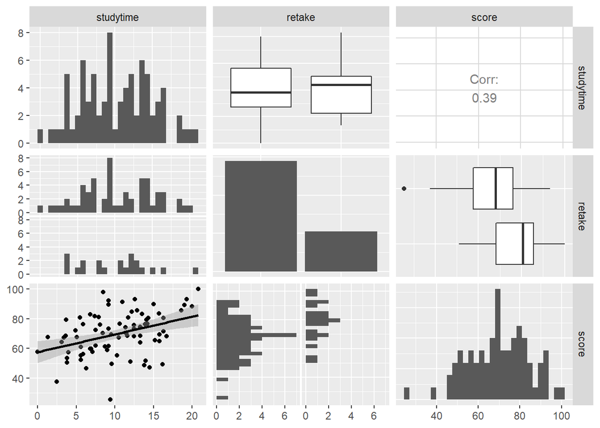

```r
ggpairs(
  tbl,
  upper = list(
    combo = "box_no_facet"
  ),
  diag = list(
    continuous = "barDiag"
  ),
  lower = list(
    continuous = "smooth"
  )
)
```

> “yes” with retake have higher mean studytime than with “no”. And “yes” with retake also have higher mean score than with “no”. Studytime have a positive corrleation with score, but with some variance.

**c) [4 pts]**

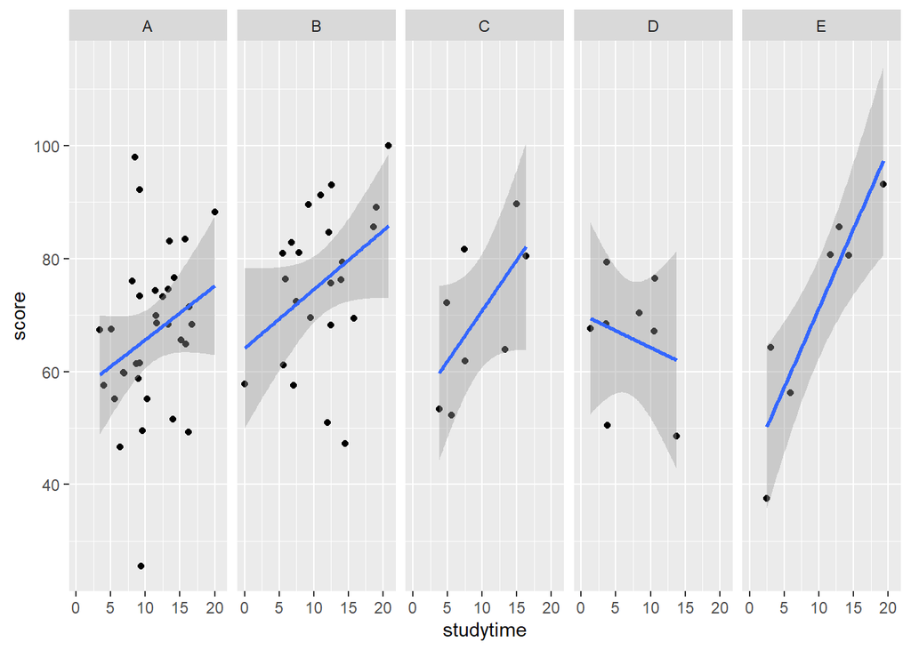

```r
ggplot(students, aes(studytime, score)) +
  geom_point() +
  geom_smooth(method = "lm") +
  facet_grid(~major)
```

**d) [4 pts]**

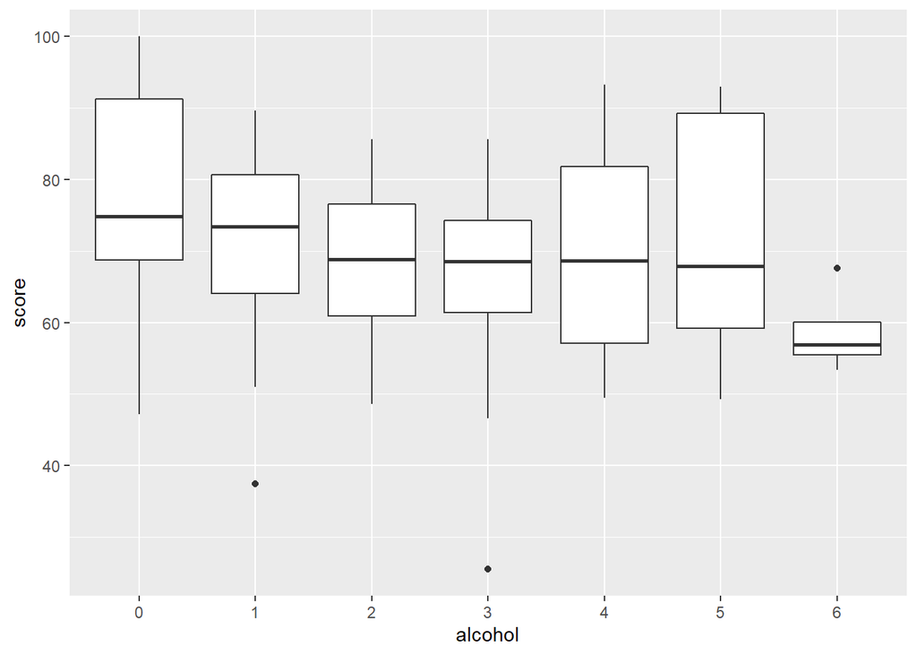

```r
ggplot(students, aes(alcohol, score)) +
  geom_boxplot()
```

> More alcohol is related with less score.

**e) [4 pts]**

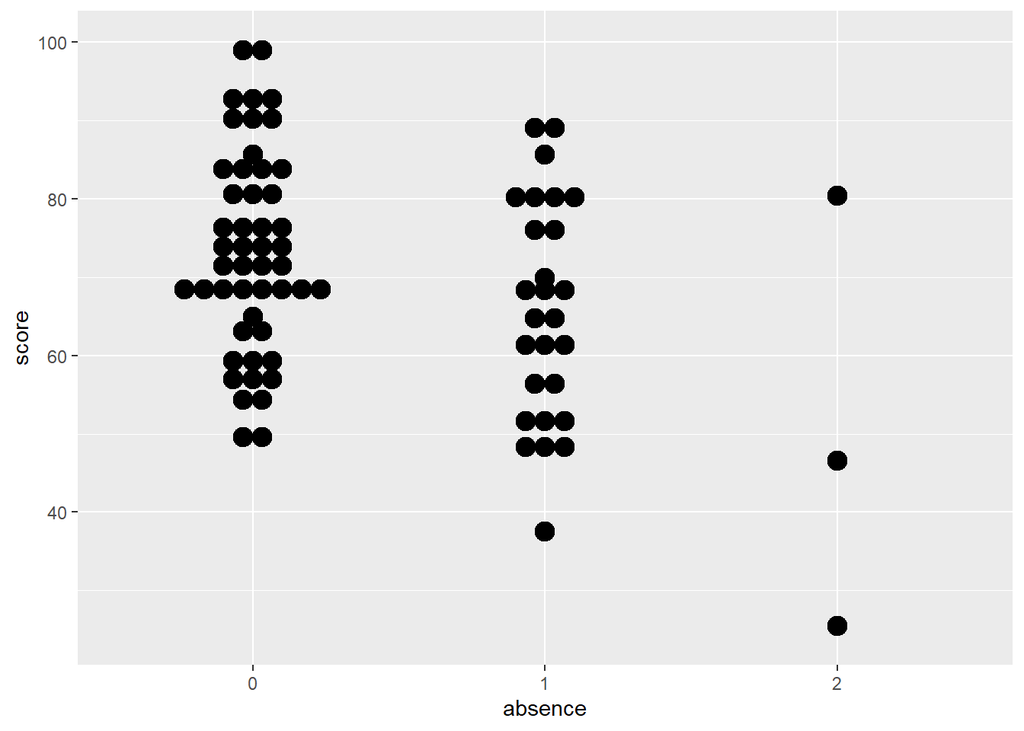

```r
ggplot(students, aes(absence, score)) +
  geom_dotplot(
    binaxis = "y",
    stackdir = "center"
  )
```

> More absence is related with less score.